# Predicting the Risk parameters for Cardiovascular patients

Abhigyan Misra

November 15th 2020

# Introduction

**Problem Statement :** Cardiovascular Disease often used interchangeably with “heart disease”, generally refers to conditions that involve narrowed or blocked blood vessels that can lead to a heart attack, chest pain (angina) or stroke. Other heart conditions, such as those that affect your heart’s muscle, valves, or rhythm, also are considered forms of heart disease. The purpose of this project is to predict the effects of different parameters recorded in the data to predict mortality of the patient. By predicting so the physicians can determine high risk patients and can take better care of them thus helping them survive.

# Reading the Data File

```r
# Load the `caTools` library
library(caTools)
# Load the `heart_failure_clinical_records_dataset.csv` as df
clinical_df <- read.csv("heart_failure_clinical_records_dataset.csv")

# Converting few attributes as factors
clinical_df$anaemia <- as.factor(clinical_df$anaemia)
clinical_df$diabetes <- as.factor(clinical_df$diabetes)
clinical_df$high_blood_pressure <- as.factor(clinical_df$high_blood_pressure)
clinical_df$sex <- as.factor(clinical_df$sex)
clinical_df$smoking <- as.factor(clinical_df$smoking)
clinical_df$DEATH_EVENT <- as.factor(clinical_df$DEATH_EVENT)
head(clinical_df)
```

```
##   age anaemia creatinine_phosphokinase diabetes ejection_fraction
## 1  75       0                      582        0                20
## 2  55       0                     7861        0                38
## 3  65       0                      146        0                20
## 4  50       1                      111        0                20
## 5  65       1                      160        1                20
## 6  90       1                       47        0                40
##   high_blood_pressure platelets serum_creatinine serum_sodium sex smoking time
## 1                   1    265000              1.9          130   1       0    4
## 2                   0    263358              1.1          136   1       0    6
## 3                   0    162000              1.3          129   1       1    7
## 4                   0    210000              1.9          137   1       0    7
## 5                   0    327000              2.7          116   0       0    8
## 6                   1    204000              2.1          132   1       1    8
##   DEATH_EVENT
## 1           1
## 2           1
## 3           1
## 4           1
## 5           1
## 6           1
```

```r
summary(clinical_df)
```

```
##       age        anaemia creatinine_phosphokinase diabetes ejection_fraction
##  Min.   :40.00   0:170   Min.   :  23.0           0:174    Min.   :14.00
##  1st Qu.:51.00   1:129   1st Qu.: 116.5           1:125    1st Qu.:30.00
##  Median :60.00           Median : 250.0                    Median :38.00
##  Mean   :60.83           Mean   : 581.8                    Mean   :38.08
##  3rd Qu.:70.00           3rd Qu.: 582.0                    3rd Qu.:45.00
##  Max.   :95.00           Max.   :7861.0                    Max.   :80.00
##  high_blood_pressure   platelets      serum_creatinine  serum_sodium   sex
##  0:194               Min.   : 25100   Min.   :0.500    Min.   :113.0   0:105
##  1:105               1st Qu.:212500   1st Qu.:0.900    1st Qu.:134.0   1:194
##                      Median :262000   Median :1.100    Median :137.0
##                      Mean   :263358   Mean   :1.394    Mean   :136.6
##                      3rd Qu.:303500   3rd Qu.:1.400    3rd Qu.:140.0
##                      Max.   :850000   Max.   :9.400    Max.   :148.0
##  smoking      time       DEATH_EVENT
##  0:203   Min.   :  4.0   0:203
##  1: 96   1st Qu.: 73.0   1: 96
##          Median :115.0
##          Mean   :130.3
##          3rd Qu.:203.0
##          Max.   :285.0
```

```r
str(clinical_df)
```

```
## 'data.frame':    299 obs. of  13 variables:
##  $ age                     : num  75 55 65 50 65 90 75 60 65 80 ...
##  $ anaemia                 : Factor w/ 2 levels "0","1": 1 1 1 2 2 2 2 2 1 2 ...
##  $ creatinine_phosphokinase: int  582 7861 146 111 160 47 246 315 157 123 ...
##  $ diabetes                : Factor w/ 2 levels "0","1": 1 1 1 1 2 1 1 2 1 1 ...
##  $ ejection_fraction       : int  20 38 20 20 20 40 15 60 65 35 ...
##  $ high_blood_pressure     : Factor w/ 2 levels "0","1": 2 1 1 1 1 2 1 1 1 2 ...
##  $ platelets               : num  265000 263358 162000 210000 327000 ...
##  $ serum_creatinine        : num  1.9 1.1 1.3 1.9 2.7 2.1 1.2 1.1 1.5 9.4 ...
##  $ serum_sodium            : int  130 136 129 137 116 132 137 131 138 133 ...
##  $ sex                     : Factor w/ 2 levels "0","1": 2 2 2 2 1 2 2 2 1 2 ...
##  $ smoking                 : Factor w/ 2 levels "0","1": 1 1 2 1 1 2 1 2 1 2 ...
##  $ time                    : int  4 6 7 7 8 8 10 10 10 10 ...
##  $ DEATH_EVENT             : Factor w/ 2 levels "0","1": 2 2 2 2 2 2 2 2 2 2 ...
```

# Data Definitions

[output not shown]

# Validation of the Data

```r
any(is.na(clinical_df))
```

```
## [1] FALSE
```

```r
nrow(clinical_df)
```

```
## [1] 299
```

```r
ncol(clinical_df)
```

```
## [1] 13
```

```r
range(clinical_df$age)
```

```
## [1] 40 95
```

```r
range(clinical_df$creatinine_phosphokinase)
```

```
## [1]   23 7861
```

```r
range(clinical_df$ejection_fraction)
```

```
## [1] 14 80
```

```r
range(clinical_df$platelets)
```

```
## [1]  25100 850000
```

```r
range(clinical_df$serum_creatinine)
```

```
## [1] 0.5 9.4
```

```r
range(clinical_df$serum_sodium)
```

```
## [1] 113 148
```

# Histogram Plots for the parameters being observed

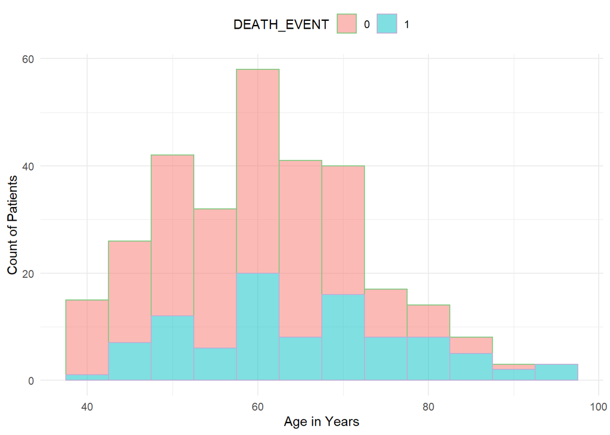

```r
library(ggplot2)

ggplot(clinical_df, aes(age, color=DEATH_EVENT, fill=DEATH_EVENT)) +
  geom_histogram(alpha=0.5, binwidth = 5)+
  #geom_density(alpha=.2, fill="#FF6666")+
  xlab("Age in Years") +
  ylab("Count of Patients") +
  scale_color_brewer(palette="Accent") +
  theme_minimal()+theme(legend.position="top")
```

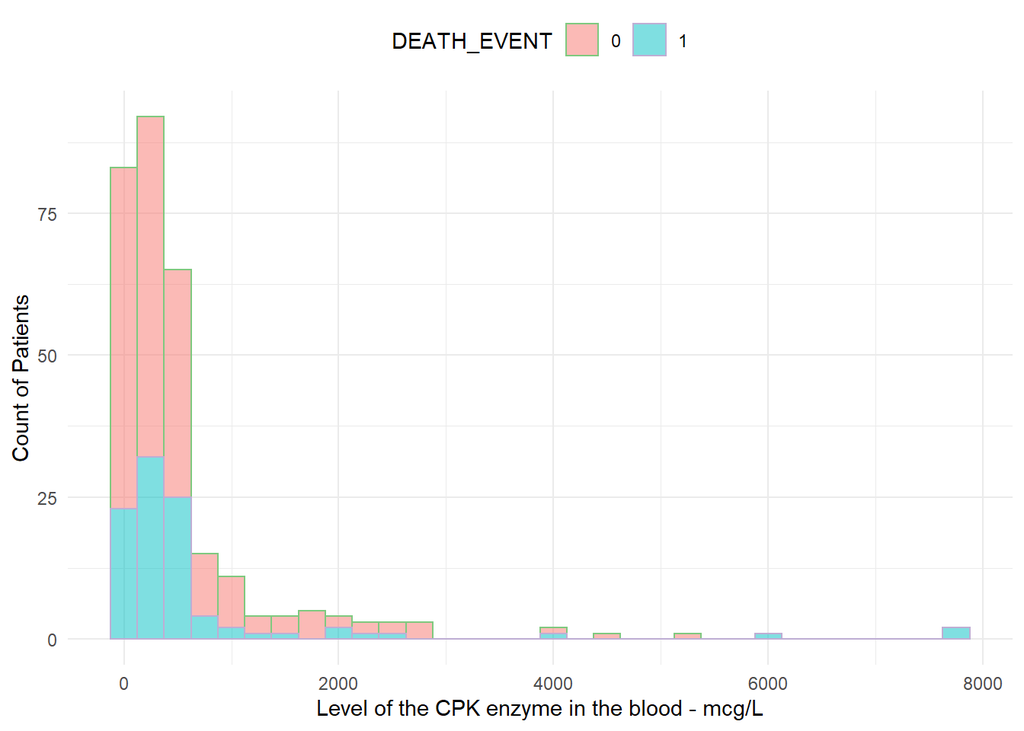

```r
ggplot(clinical_df, aes(creatinine_phosphokinase, color=DEATH_EVENT, fill=DEATH_EVENT)) +
  geom_histogram(alpha=0.5, binwidth = 250)+
  #geom_density(alpha=.2, fill="#FF6666")+
  xlab("Level of the CPK enzyme in the blood - mcg/L") +
  ylab("Count of Patients")+
  scale_color_brewer(palette="Accent") +
  theme_minimal()+theme(legend.position="top")
```

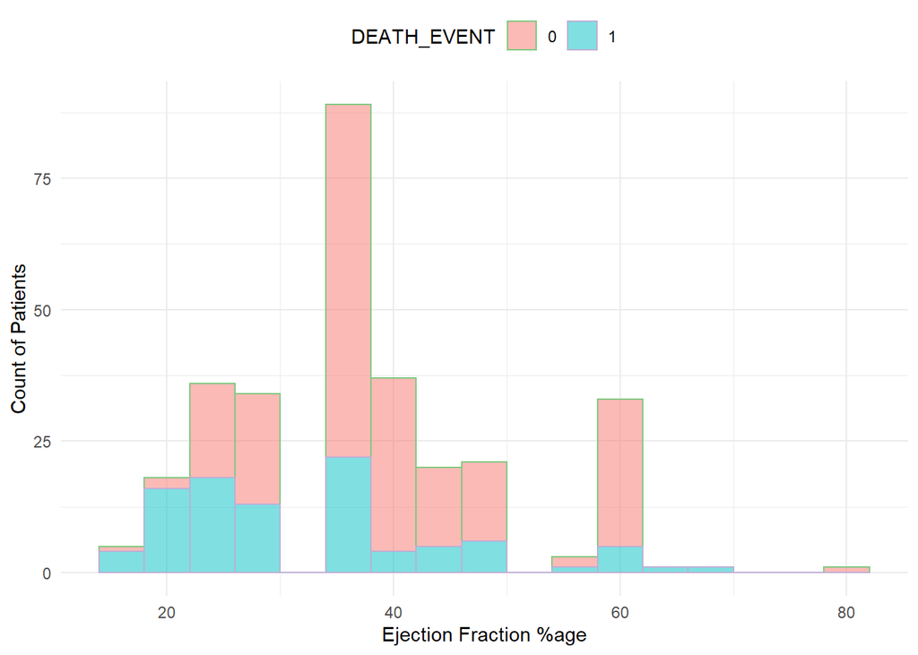

```r
ggplot(clinical_df, aes(ejection_fraction, color=DEATH_EVENT, fill=DEATH_EVENT)) +
  geom_histogram(alpha=0.5, binwidth = 4)+
  #geom_density(alpha=.2, fill="#FF6666")+
  xlab("Ejection Fraction %age") +
  ylab("Count of Patients")+
  scale_color_brewer(palette="Accent") +
  theme_minimal()+theme(legend.position="top")
```

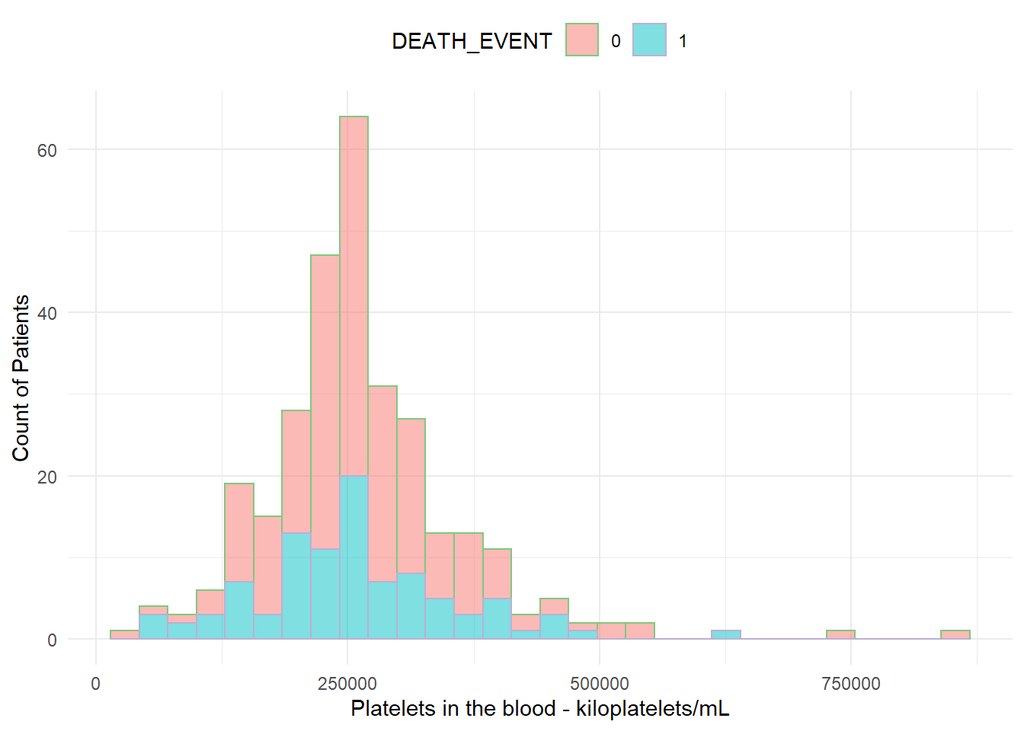

```r
ggplot(clinical_df, aes(platelets, color=DEATH_EVENT, fill=DEATH_EVENT)) +
  geom_histogram(alpha=0.5)+
  #geom_density(alpha=.2, fill="#FF6666")+
  xlab("Platelets in the blood - kiloplatelets/mL") +
  ylab("Count of Patients")+
  scale_color_brewer(palette="Accent") +
  theme_minimal()+theme(legend.position="top")
```

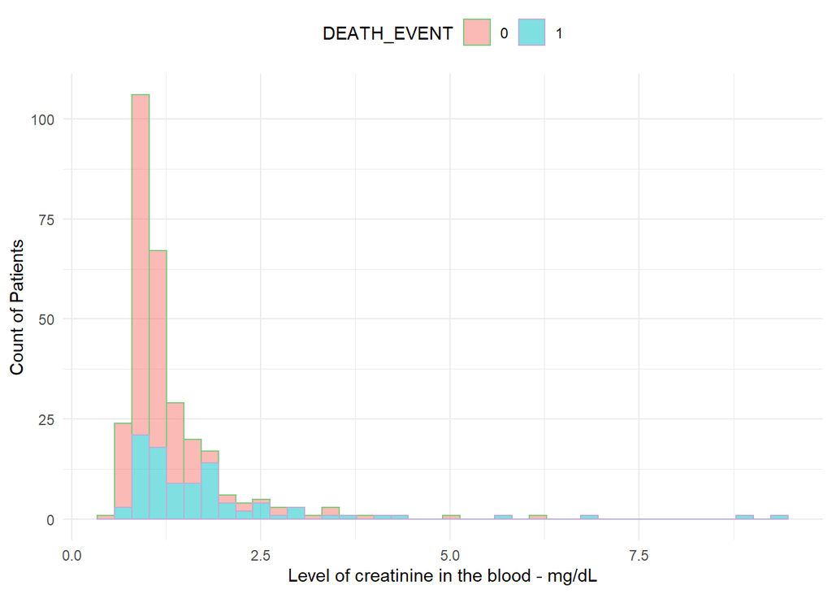

```r
ggplot(clinical_df, aes(serum_creatinine, color=DEATH_EVENT, fill=DEATH_EVENT)) +
  geom_histogram(alpha=0.5, bins = 40)+
  #geom_density(alpha=.2, fill="#FF6666")+
  xlab("Level of creatinine in the blood - mg/dL") +
  ylab("Count of Patients")+
  scale_color_brewer(palette="Accent") +
  theme_minimal()+theme(legend.position="top")
```

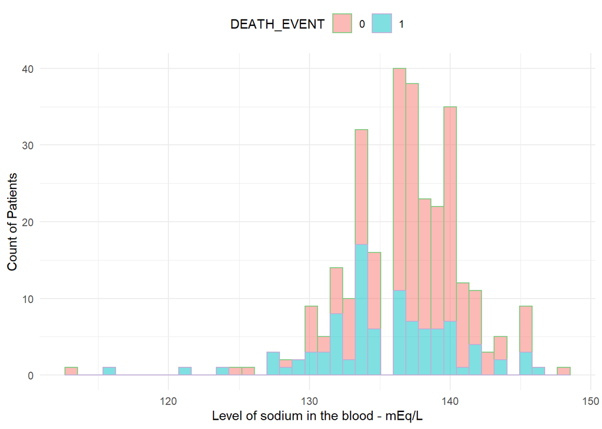

```r
ggplot(clinical_df, aes(serum_sodium, color=DEATH_EVENT, fill=DEATH_EVENT)) +
  geom_histogram(alpha=0.5, bins = 40)+
  #geom_density(alpha=.2, fill="#FF6666")+
  xlab("Level of sodium in the blood - mEq/L") +
  ylab("Count of Patients") +
  scale_color_brewer(palette="Accent") +
  theme_minimal()+theme(legend.position="top")
```

The histogram plots are for comparing the effect of the parameters in case of a Death Event or Survival. To further clearly see the impact it’s better to have the density plots to see, if some parameters show more effect than the others.

# Density Plots for the parameters being observed

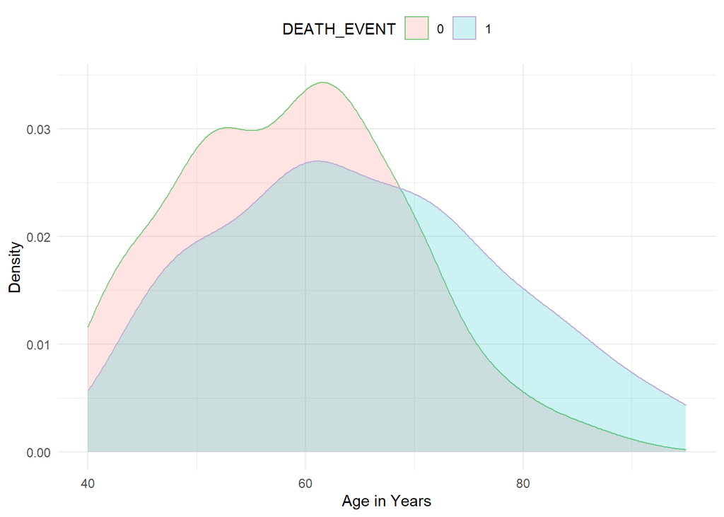

```r
ggplot(clinical_df, aes(age, color=DEATH_EVENT, fill=DEATH_EVENT)) +
  #geom_histogram(aes(y=..density..), alpha=0.5, binwidth = 5)+
  geom_density(alpha=.2)+
  xlab("Age in Years") +
  ylab("Density") +
  scale_color_brewer(palette="Accent") +
  theme_minimal()+theme(legend.position="top")
```

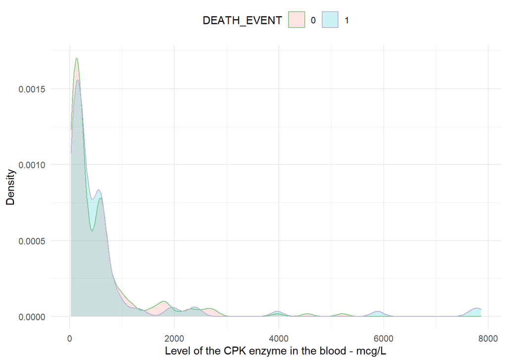

```r
ggplot(clinical_df, aes(creatinine_phosphokinase, color=DEATH_EVENT, fill=DEATH_EVENT)) +
  #geom_histogram(aes(y=..density..), alpha=0.5, binwidth = 250)+
  geom_density(alpha=.2)+
  xlab("Level of the CPK enzyme in the blood - mcg/L") +
  ylab("Density") +
  scale_color_brewer(palette="Accent") +
  theme_minimal()+theme(legend.position="top")
```

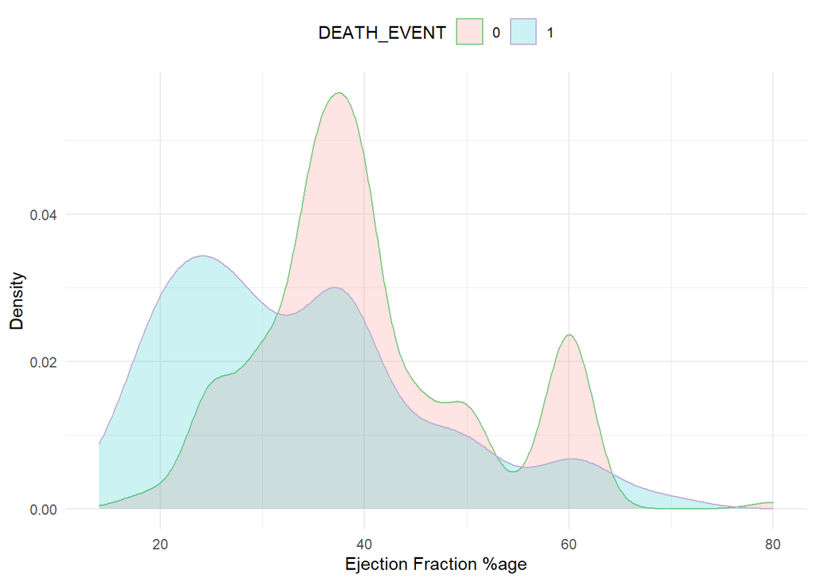

```r
ggplot(clinical_df, aes(ejection_fraction, color=DEATH_EVENT, fill=DEATH_EVENT)) +
  #geom_histogram(aes(y=..density..), alpha=0.5, binwidth = 4)+
  geom_density(alpha=.2)+
  xlab("Ejection Fraction %age") +
  ylab("Density") +
  scale_color_brewer(palette="Accent") +
  theme_minimal()+theme(legend.position="top")
```

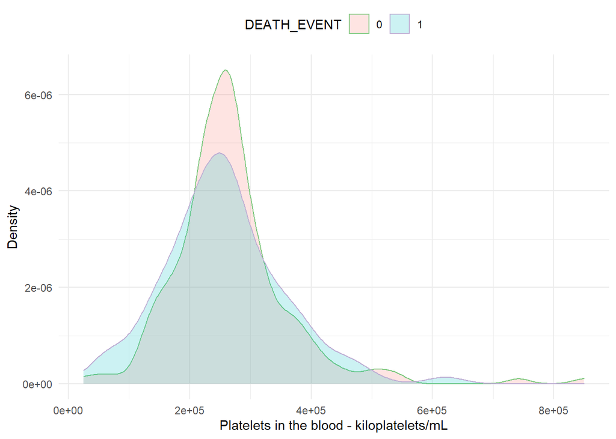

```r
ggplot(clinical_df, aes(platelets, color=DEATH_EVENT, fill=DEATH_EVENT)) +
  #geom_histogram(aes(y=..density..), alpha=0.5)+
  geom_density(alpha=.2)+
  xlab("Platelets in the blood - kiloplatelets/mL") +
  ylab("Density") +
  scale_color_brewer(palette="Accent") +
  theme_minimal()+theme(legend.position="top")
```

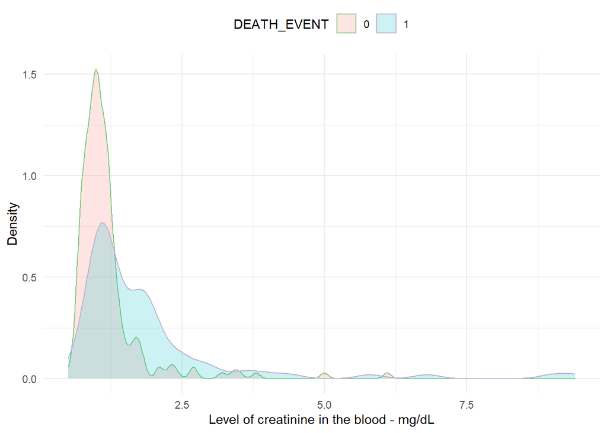

```r
ggplot(clinical_df, aes(serum_creatinine, color=DEATH_EVENT, fill=DEATH_EVENT)) +
  #geom_histogram(aes(y=..density..), alpha=0.5, bins = 40)+
  geom_density(alpha=.2)+
  xlab("Level of creatinine in the blood - mg/dL") +
  ylab("Density") +
  scale_color_brewer(palette="Accent") +
  theme_minimal()+theme(legend.position="top")
```

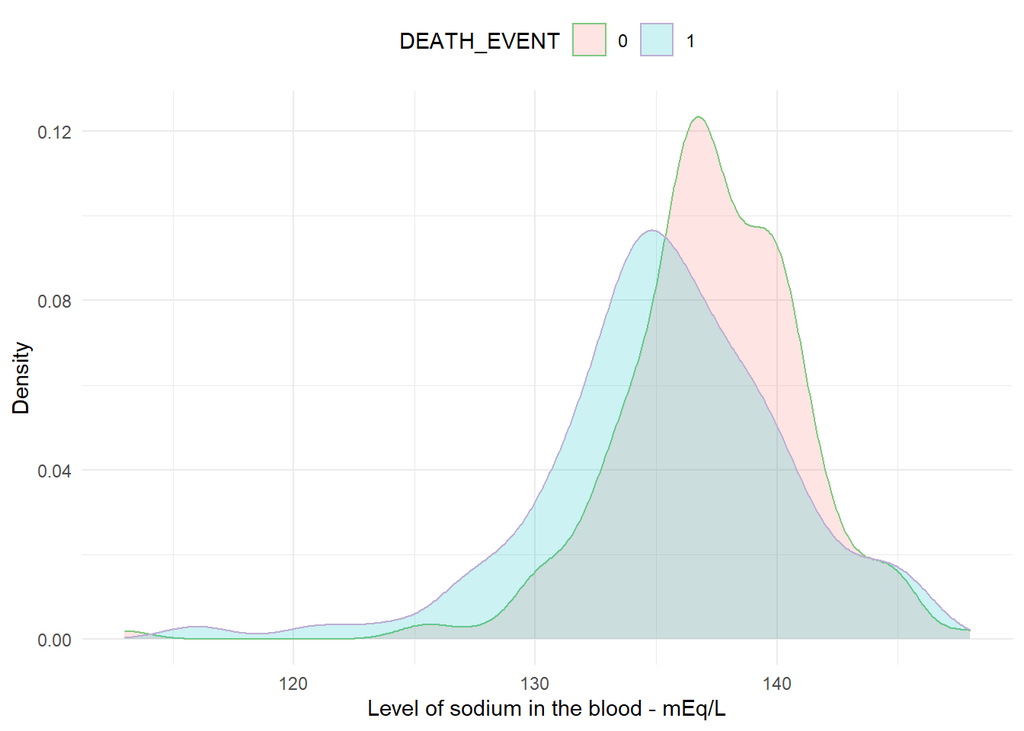

```r
ggplot(clinical_df, aes(serum_sodium, color=DEATH_EVENT, fill=DEATH_EVENT)) +
  #geom_histogram(aes(y=..density..), alpha=0.5, bins = 40)+
  geom_density(alpha=.2) +
  xlab("Level of sodium in the blood - mEq/L") +
  ylab("Density") +
  scale_color_brewer(palette="Accent") +
  theme_minimal()+theme(legend.position="top")
```

Based on the Density Plot, following is the analysis

1. Age seems to have some effect on Mortality. Older the patient, higher the risk
2. Effect of Level of CPK Enzyme is difficult to observe from the plot
3. Lesser the Ejection Fraction, risk seems to increase
4. Effect of Platelet count is difficult to observe from the plot
5. Level of Creatinine seems to have effect. Risk increases with its increase
6. Level of Sodium seems to have effect. Risk increases with its decrease

# Checking Significance of the parameters from the whole dataset.

Before proceeding with model generation, want to see what attributes are more significant for the purpose of modeling. Based on the same, we can see below parameters in order of their significance. 1. time - this is time between follow up visits 2. ejection_fraction 3. serum_creatinine 4. age 5. serum_sodium

```r
lrmodel.base <- glm(DEATH_EVENT ~ . , family ='binomial' , data = clinical_df)
summary(lrmodel.base)
```

```
##
## Call:
## glm(formula = DEATH_EVENT ~ ., family = "binomial", data = clinical_df)
##
## Deviance Residuals:
##     Min       1Q   Median       3Q      Max
## -2.1848  -0.5706  -0.2401   0.4466   2.6668
##
## Coefficients:
##                            Estimate Std. Error z value Pr(>|z|)
## (Intercept)               1.018e+01  5.657e+00   1.801 0.071774 .
## age                       4.742e-02  1.580e-02   3.001 0.002690 **
## anaemia1                 -7.470e-03  3.605e-01  -0.021 0.983467
## creatinine_phosphokinase  2.222e-04  1.779e-04   1.249 0.211684
## diabetes1                 1.451e-01  3.512e-01   0.413 0.679380
## ejection_fraction        -7.666e-02  1.633e-02  -4.695 2.67e-06 ***
## high_blood_pressure1     -1.027e-01  3.587e-01  -0.286 0.774688
## platelets                -1.200e-06  1.889e-06  -0.635 0.525404
## serum_creatinine          6.661e-01  1.815e-01   3.670 0.000242 ***
## serum_sodium             -6.698e-02  3.974e-02  -1.686 0.091855 .
## sex1                     -5.337e-01  4.139e-01  -1.289 0.197299
## smoking1                 -1.349e-02  4.126e-01  -0.033 0.973915
## time                     -2.104e-02  3.014e-03  -6.981 2.92e-12 ***
## ---
## Signif. codes:  0 '***' 0.001 '**' 0.01 '*' 0.05 '.' 0.1 ' ' 1
##
## (Dispersion parameter for binomial family taken to be 1)
##
##     Null deviance: 375.35  on 298  degrees of freedom
## Residual deviance: 219.55  on 286  degrees of freedom
## AIC: 245.55
##
## Number of Fisher Scoring iterations: 6
```

# Splitting the data into train and test datasets

```r
# Splitting the dataset for the model into train and test datasets.
set.seed(100)
myData <- sample.split(clinical_df$DEATH_EVENT, SplitRatio=0.8)

train <- subset(clinical_df, myData==TRUE)
test <- subset(clinical_df, myData==FALSE)
```

# Logistic Regression Model - Since Outcome is Binary

## Model 1

This model is based on all the attributes.

```r
# This model includes all other parameters as dependent
lrmodel.1 <- glm(DEATH_EVENT ~ . , family ='binomial' , data = train)
summary(lrmodel.1)
```

```
##
## Call:
## glm(formula = DEATH_EVENT ~ ., family = "binomial", data = train)
##
## Deviance Residuals:
##     Min       1Q   Median       3Q      Max
## -2.2755  -0.5674  -0.1969   0.4403   2.6474
##
## Coefficients:
##                            Estimate Std. Error z value Pr(>|z|)
## (Intercept)               1.971e+01  7.345e+00   2.683  0.00730 **
## age                       3.979e-02  1.760e-02   2.260  0.02380 *
## anaemia1                 -2.034e-01  4.294e-01  -0.474  0.63569
## creatinine_phosphokinase  1.814e-04  1.880e-04   0.965  0.33459
## diabetes1                 9.637e-02  4.071e-01   0.237  0.81285
## ejection_fraction        -7.806e-02  1.985e-02  -3.932 8.42e-05 ***
## high_blood_pressure1     -1.732e-01  4.272e-01  -0.405  0.68512
## platelets                -2.140e-07  2.046e-06  -0.105  0.91672
## serum_creatinine          7.831e-01  3.133e-01   2.500  0.01243 *
## serum_sodium             -1.357e-01  5.163e-02  -2.628  0.00859 **
## sex1                     -3.332e-01  4.673e-01  -0.713  0.47583
## smoking1                 -1.683e-01  4.581e-01  -0.367  0.71332
## time                     -2.109e-02  3.453e-03  -6.108 1.01e-09 ***
## ---
## Signif. codes:  0 '***' 0.001 '**' 0.01 '*' 0.05 '.' 0.1 ' ' 1
##
## (Dispersion parameter for binomial family taken to be 1)
##
##     Null deviance: 300.42  on 238  degrees of freedom
## Residual deviance: 168.62  on 226  degrees of freedom
## AIC: 194.62
##
## Number of Fisher Scoring iterations: 6
```

## Model 2

This model is based on all significant parameters except time between follow ups. Want to remove time between follow ups as its not a vital reading from person’s blood work.

```r
# Trying out another model
# This model includes only parameters which showed the effect in density plot
lrmodel.2 <- glm(DEATH_EVENT ~ age + ejection_fraction + serum_creatinine + serum_sodium  , family ='binomial' , data = train)

summary(lrmodel.2)
```

```
##
## Call:
## glm(formula = DEATH_EVENT ~ age + ejection_fraction + serum_creatinine +
##     serum_sodium, family = "binomial", data = train)
##
## Deviance Residuals:
##     Min       1Q   Median       3Q      Max
## -1.8853  -0.7688  -0.4896   0.8113   2.3820
##
## Coefficients:
##                   Estimate Std. Error z value Pr(>|z|)
## (Intercept)       14.70337    5.60464   2.623  0.00871 **
## age                0.04475    0.01406   3.184  0.00145 **
## ejection_fraction -0.06609    0.01695  -3.899 9.66e-05 ***
## serum_creatinine   0.73975    0.25898   2.856  0.00429 **
## serum_sodium      -0.12359    0.04041  -3.058  0.00223 **
## ---
## Signif. codes:  0 '***' 0.001 '**' 0.01 '*' 0.05 '.' 0.1 ' ' 1
##
## (Dispersion parameter for binomial family taken to be 1)
##
##     Null deviance: 300.42  on 238  degrees of freedom
## Residual deviance: 233.75  on 234  degrees of freedom
## AIC: 243.75
##
## Number of Fisher Scoring iterations: 5
```

## Model 3

Generating another model with all significant parameters along with time between follow ups.

```r
# Trying out another model
# This model includes only parameters which showed the effect in density plot + time, as it shows significance. time is the time in days between follow up visits.
lrmodel.3 <- glm(DEATH_EVENT ~ age + ejection_fraction + serum_creatinine + serum_sodium + time  , family ='binomial' , data = train)

summary(lrmodel.3)
```

```
##
## Call:
## glm(formula = DEATH_EVENT ~ age + ejection_fraction + serum_creatinine +
##     serum_sodium + time, family = "binomial", data = train)
##
## Deviance Residuals:
##     Min       1Q   Median       3Q      Max
## -2.0861  -0.5860  -0.1970   0.4859   2.7572
##
## Coefficients:
##                    Estimate Std. Error z value Pr(>|z|)
## (Intercept)       19.450893   7.179964   2.709  0.00675 **
## age                0.036476   0.016924   2.155  0.03114 *
## ejection_fraction -0.076867   0.019427  -3.957 7.60e-05 ***
## serum_creatinine   0.768715   0.304184   2.527  0.01150 *
## serum_sodium      -0.135128   0.050741  -2.663  0.00774 **
## time              -0.020720   0.003256  -6.363 1.98e-10 ***
## ---
## Signif. codes:  0 '***' 0.001 '**' 0.01 '*' 0.05 '.' 0.1 ' ' 1
##
## (Dispersion parameter for binomial family taken to be 1)
##
##     Null deviance: 300.42  on 238  degrees of freedom
## Residual deviance: 170.96  on 233  degrees of freedom
## AIC: 182.96
##
## Number of Fisher Scoring iterations: 6
```

## Model 4

```r
# Trying out another model
# This model includes only parameters which showed the effect in density plot + time, as it shows significance. time is the time in days between follow up visits.
lrmodel.4 <- glm(DEATH_EVENT ~ ejection_fraction + serum_creatinine + serum_sodium, family ='binomial' , data = train)

summary(lrmodel.4)
```

```
##
## Call:
## glm(formula = DEATH_EVENT ~ ejection_fraction + serum_creatinine +
##     serum_sodium, family = "binomial", data = train)
##
## Deviance Residuals:
##     Min       1Q   Median       3Q      Max
## -2.3720  -0.7842  -0.5585   0.8924   2.2242
##
## Coefficients:
##                   Estimate Std. Error z value Pr(>|z|)
## (Intercept)       16.87592    5.62565   3.000 0.002701 **
## ejection_fraction -0.05398    0.01576  -3.426 0.000613 ***
## serum_creatinine   0.87424    0.26293   3.325 0.000884 ***
## serum_sodium      -0.12365    0.04065  -3.042 0.002351 **
## ---
## Signif. codes:  0 '***' 0.001 '**' 0.01 '*' 0.05 '.' 0.1 ' ' 1
##
## (Dispersion parameter for binomial family taken to be 1)
##
##     Null deviance: 300.42  on 238  degrees of freedom
## Residual deviance: 244.38  on 235  degrees of freedom
## AIC: 252.38
##
## Number of Fisher Scoring iterations: 5
```

# Plot the Models

## Model 1

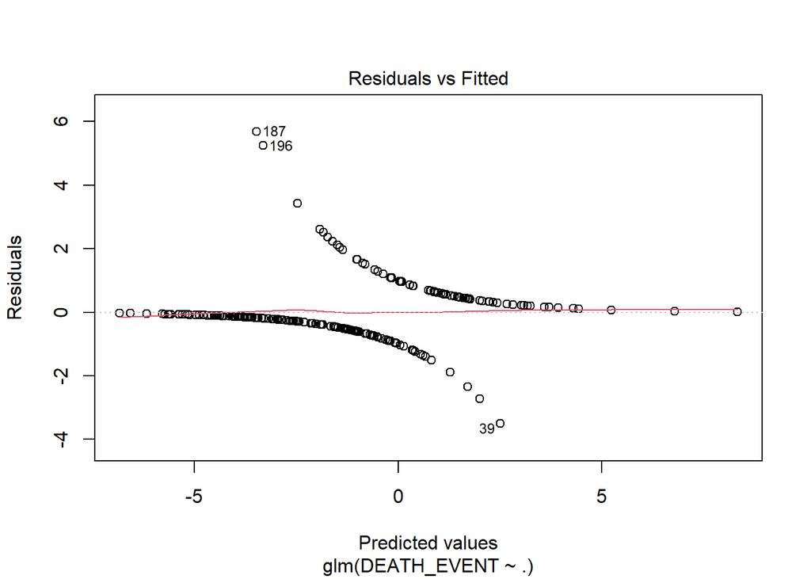

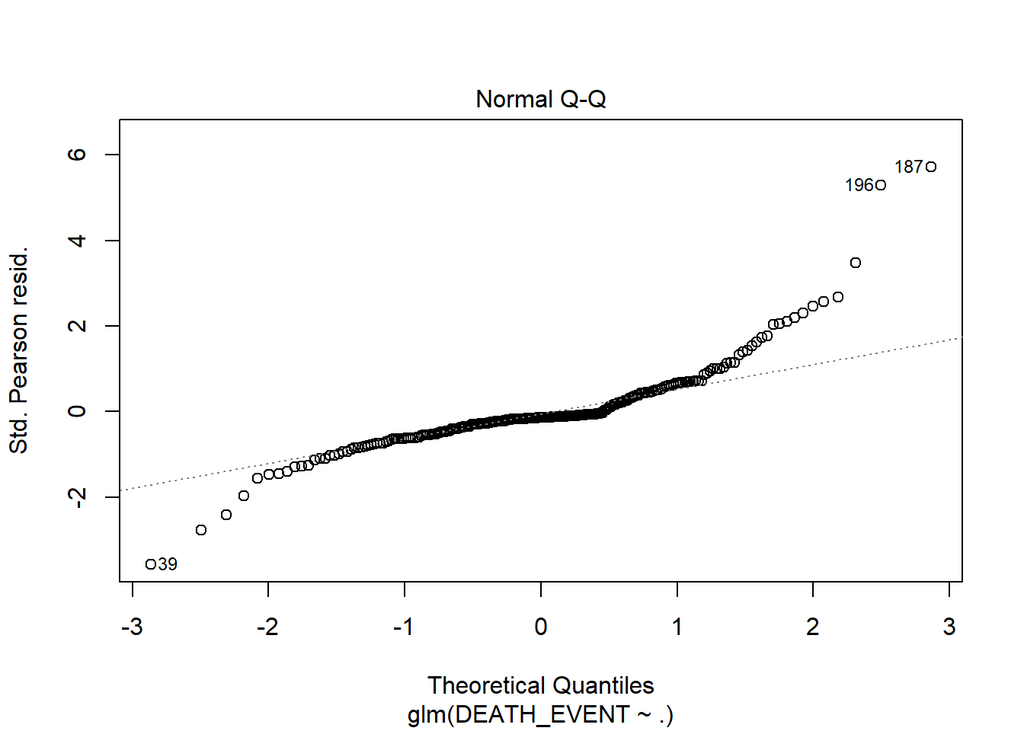

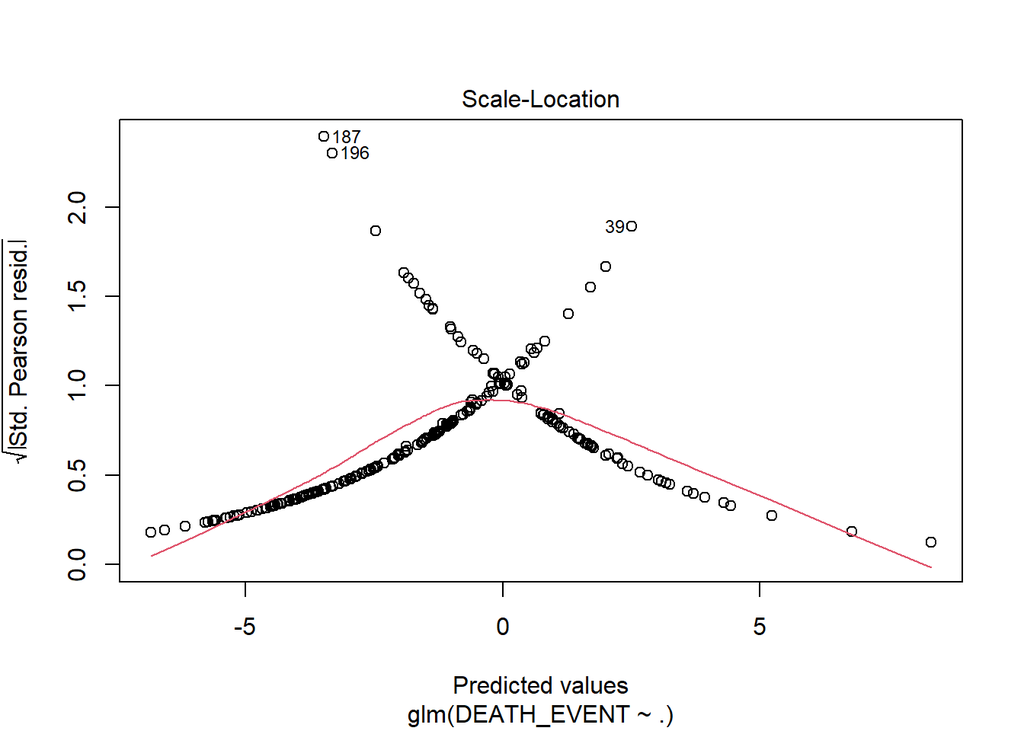

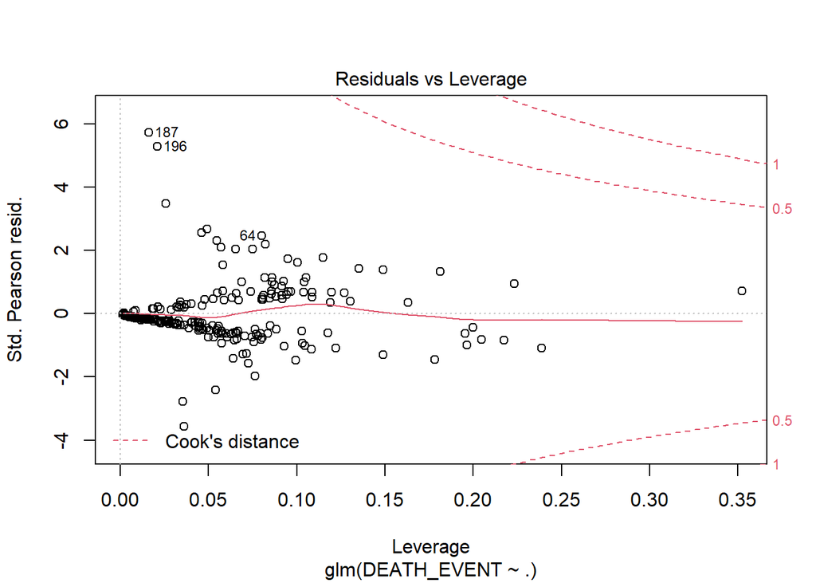

```r
plot(lrmodel.1)
```

## Model 2

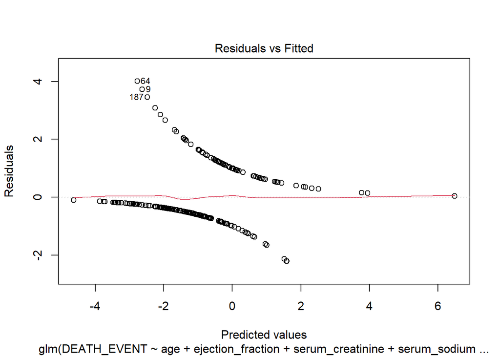

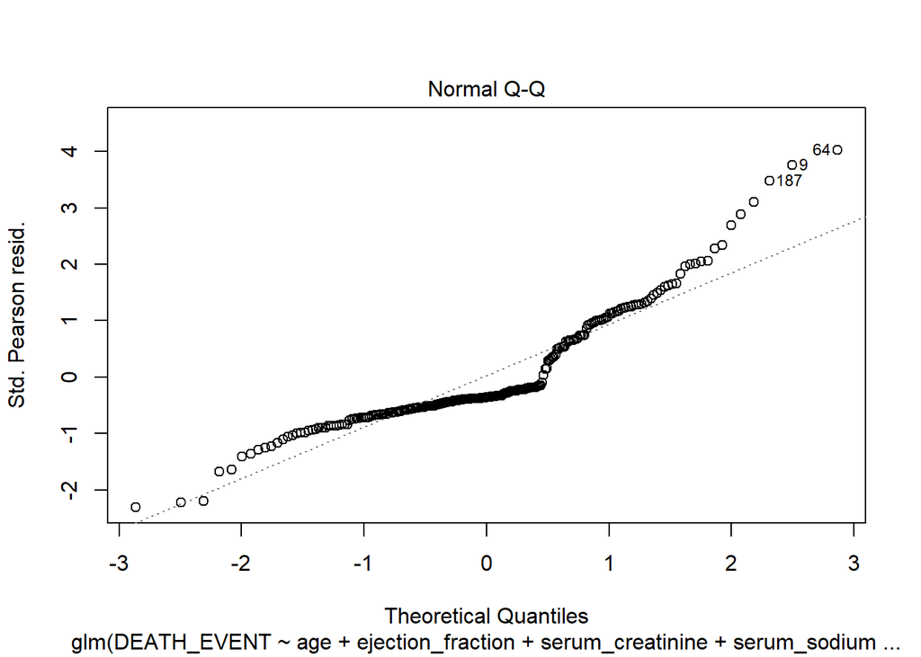

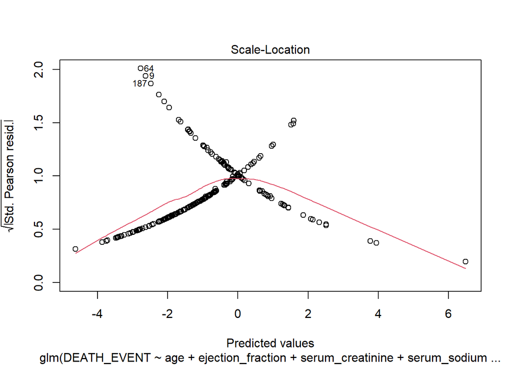

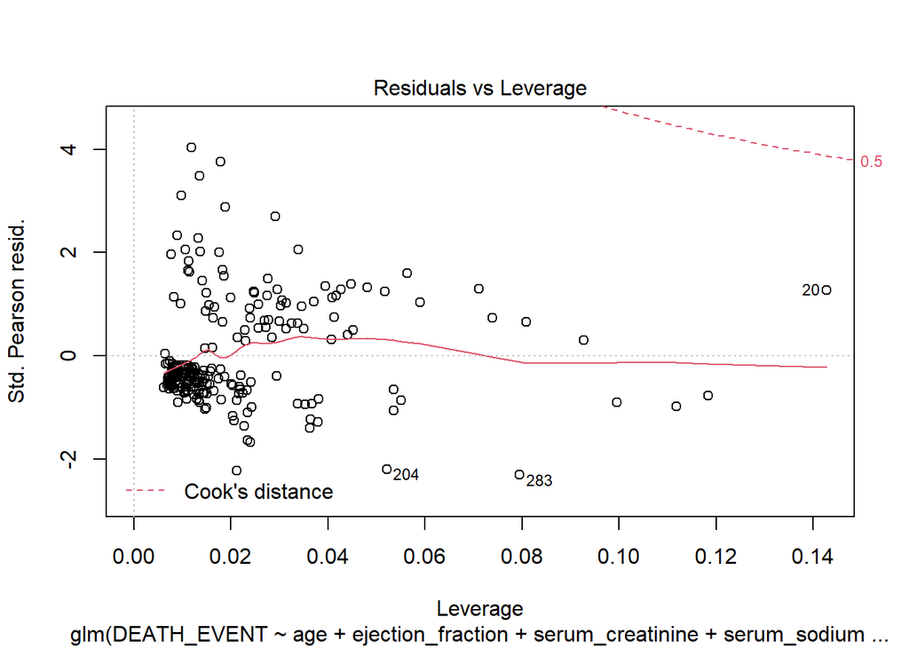

```r
plot(lrmodel.2)
```

## Model 3

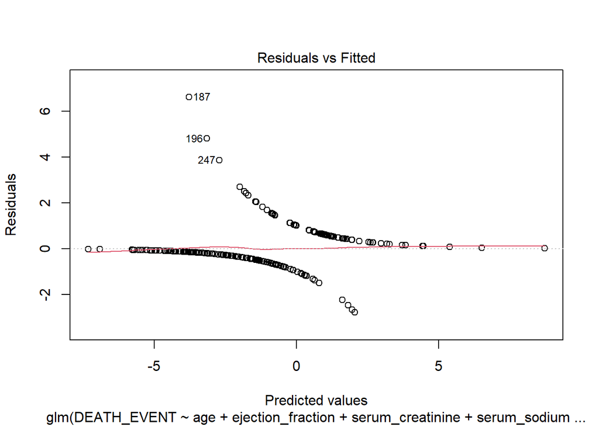

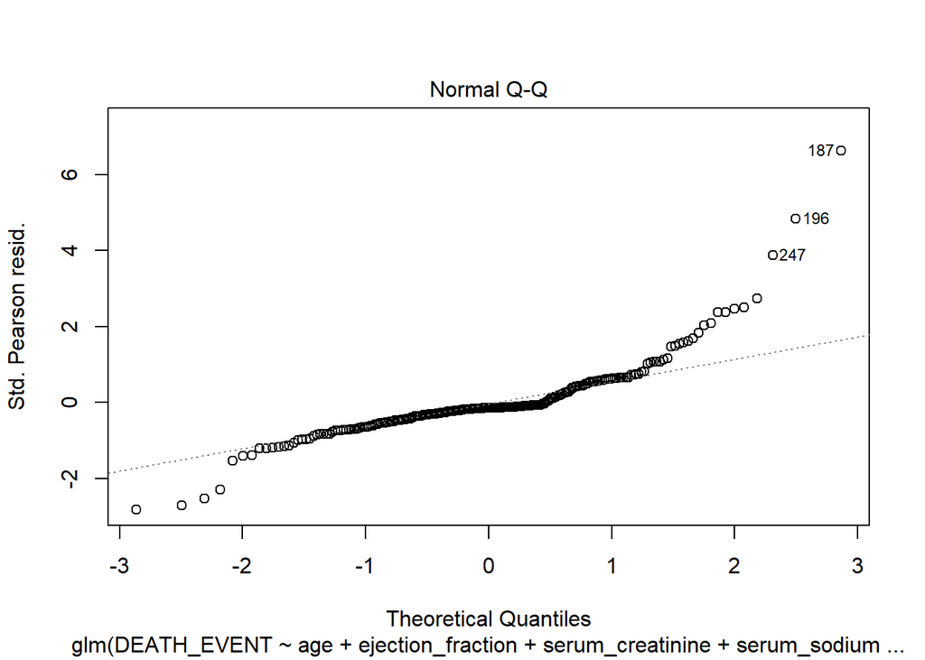

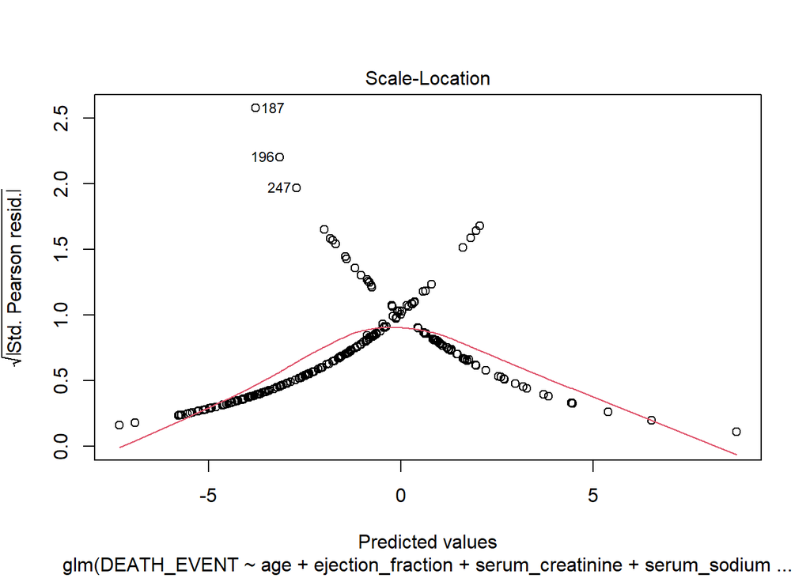

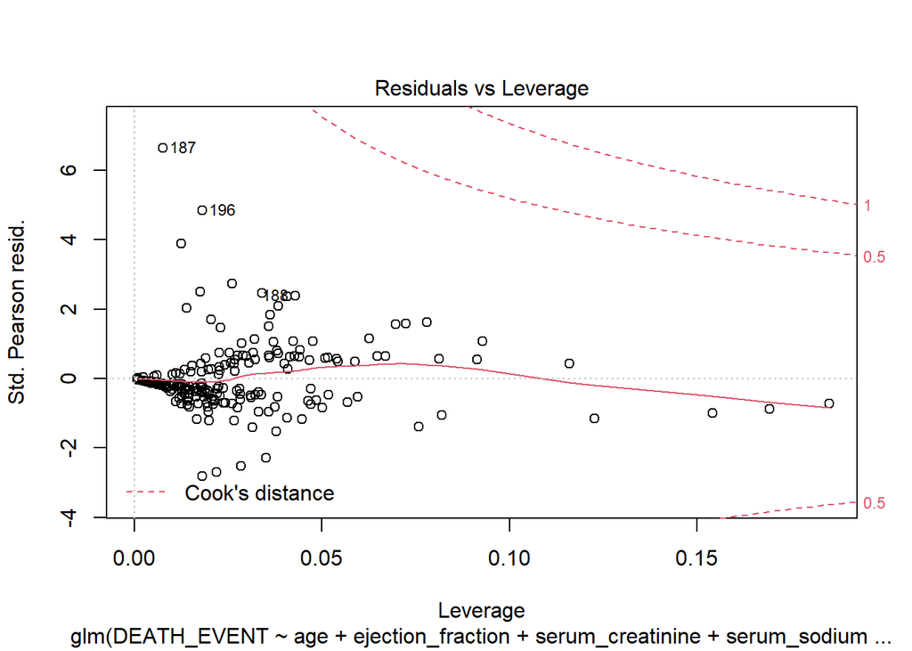

```r
plot(lrmodel.3)
```

## Model 4

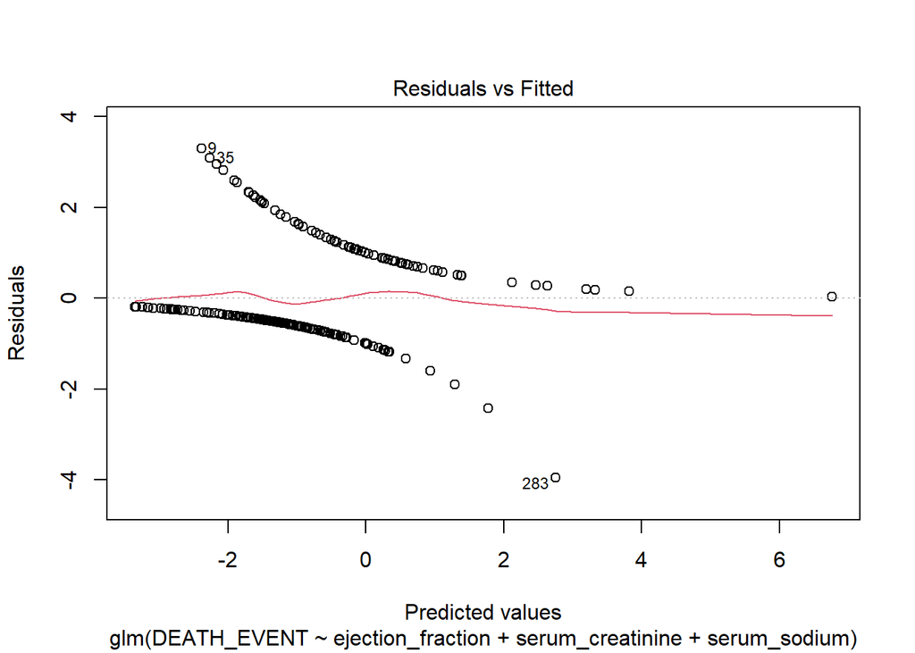

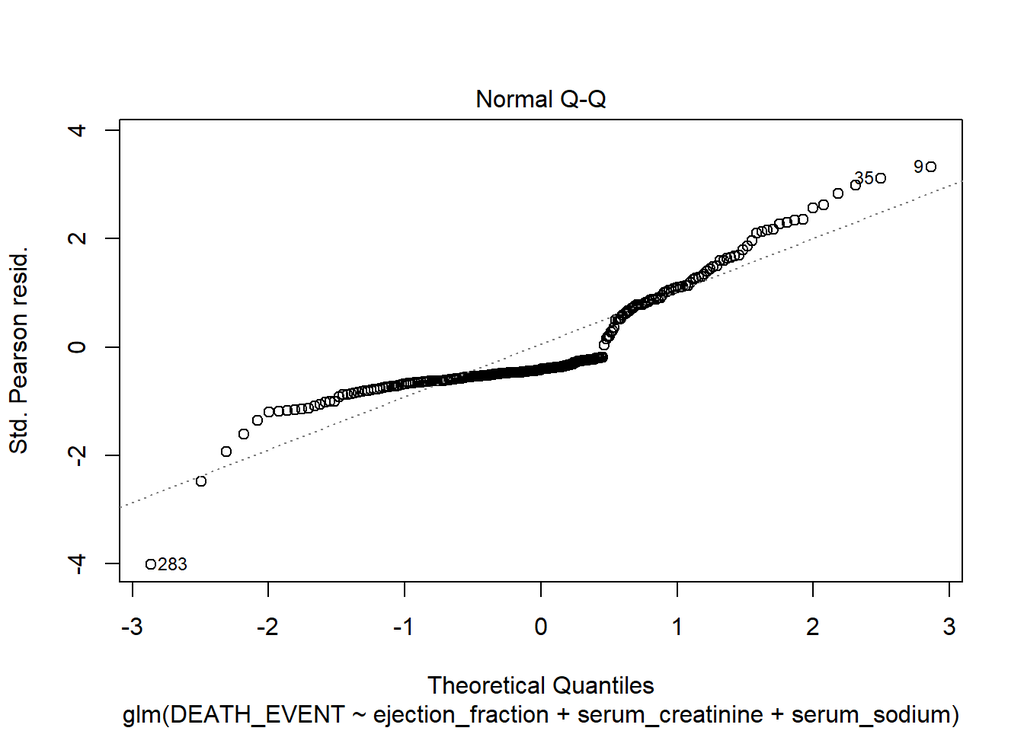

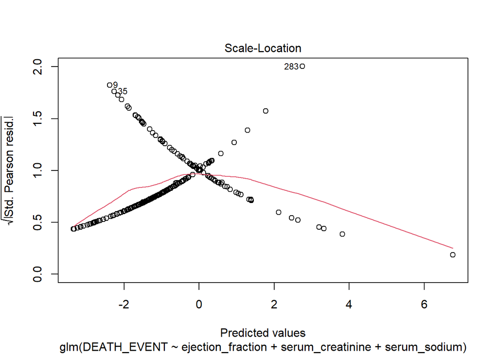

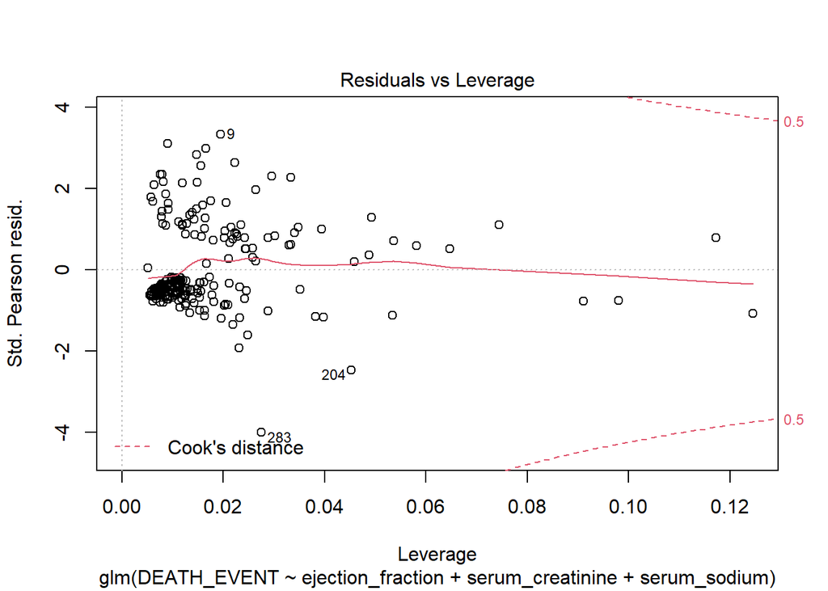

```r
plot(lrmodel.4)
```

## Comparing the Models

```r
anova(lrmodel.1, lrmodel.2, lrmodel.3, lrmodel.4, test = "Chisq")
```

```
## Analysis of Deviance Table
##
## Model 1: DEATH_EVENT ~ age + anaemia + creatinine_phosphokinase + diabetes +
##     ejection_fraction + high_blood_pressure + platelets + serum_creatinine +
##     serum_sodium + sex + smoking + time
## Model 2: DEATH_EVENT ~ age + ejection_fraction + serum_creatinine + serum_sodium
## Model 3: DEATH_EVENT ~ age + ejection_fraction + serum_creatinine + serum_sodium +
##     time
## Model 4: DEATH_EVENT ~ ejection_fraction + serum_creatinine + serum_sodium
##   Resid. Df Resid. Dev Df Deviance  Pr(>Chi)
## 1       226     168.62
## 2       234     233.75 -8  -65.132 4.545e-11 ***
## 3       233     170.96  1   62.792 2.297e-15 ***
## 4       235     244.38 -2  -73.415 < 2.2e-16 ***
## ---
## Signif. codes:  0 '***' 0.001 '**' 0.01 '*' 0.05 '.' 0.1 ' ' 1
```

Based on the comparison, Model 3 seems to be better than Model 1, Model 2 & Model 4. Also if you look at the QQ plot of the models, Model 3 is better aligned, though it does seem to have outliers as shown in the plot.

## Testing Model 3 for Multicollinearity

```r
library(car)
vif(lrmodel.3)
```

```
##               age ejection_fraction  serum_creatinine      serum_sodium
##          1.090910          1.158364          1.044194          1.054396
##              time
##          1.108521
```

```r
print("Tolerance = 1/VIF")
```

```
## [1] "Tolerance = 1/VIF"
```

```r
1/vif(lrmodel.3)
```

```
##               age ejection_fraction  serum_creatinine      serum_sodium
##         0.9166657         0.8632868         0.9576765         0.9484103
##              time
##         0.9021027
```

```r
print("Mean VIF")
```

```
## [1] "Mean VIF"
```

```r
mean(vif(lrmodel.3))
```

```
## [1] 1.091277
```

Is Largest VIF > 10 ? NO - So no cause for concern Avg VIF is 1.091277, which is not substantially greater than 1. (Substantially more is considered more than 2.5, as from https://statisticalhorizons.com/multicollinearity) All Tolerance are above 0.2, meaning it should be fine.(Less than 0.2 is potential problem, less than 0.1 is significant problem. Its same as VIF >10, as tolerance = 1/VIF)

# Checking Accuracy of Models

## Model 1

```r
# Using test dataset to see if the model is good
result <- predict(lrmodel.1,test,type = "response")
# result
# validating - putting the actual value and counts of Predicted values in a matrix
# Setting to T if result > 0.5
confmatrix <- table(ActualValue=test$DEATH_EVENT, PredictedValue = result > 0.5)
confmatrix
```

```
##            PredictedValue
## ActualValue FALSE TRUE
##           0    36    5
##           1    11    8
```

```r
# accuracy - Cases where we predicted correctly by Total Predictions
(confmatrix[1,1]+confmatrix[2,2])/sum(confmatrix)
```

```
## [1] 0.7333333
```

## Model 2

```r
# Using test dataset to see if the model is good
# Using test dataset to see if the model is good
result <- predict(lrmodel.2,test,type = "response")
# result
# validating - putting the actual value and counts of Predicted values in a matrix
# Setting to T if result > 0.5
confmatrix <- table(ActualValue=test$DEATH_EVENT, PredictedValue = result > 0.5)
confmatrix
```

```
##            PredictedValue
## ActualValue FALSE TRUE
##           0    36    5
##           1     9   10
```

```r
# accuracy - Cases where we predicted correctly by Total Predictions
(confmatrix[1,1]+confmatrix[2,2])/sum(confmatrix)
```

```
## [1] 0.7666667
```

## Model 3

```r
# Using test dataset to see if the model is good
result <- predict(lrmodel.3,test,type = "response")
# result
# validating - putting the actual value and counts of Predicted values in a matrix
# Setting to T if result > 0.5
confmatrix <- table(ActualValue=test$DEATH_EVENT, PredictedValue = result > 0.5)
confmatrix
```

```
##            PredictedValue
## ActualValue FALSE TRUE
##           0    36    5
##           1     9   10
```

```r
# accuracy - Cases where we predicted correctly by Total Predictions
(confmatrix[1,1]+confmatrix[2,2])/sum(confmatrix)
```

```
## [1] 0.7666667
```

## Model 4

```r
# Using test dataset to see if the model is good
result <- predict(lrmodel.4,test,type = "response")
# result
# validating - putting the actual value and counts of Predicted values in a matrix
# Setting to T if result > 0.5
confmatrix <- table(ActualValue=test$DEATH_EVENT, PredictedValue = result > 0.5)
confmatrix
```

```
##            PredictedValue
## ActualValue FALSE TRUE
##           0    36    5
##           1    12    7
```

```r
# accuracy - Cases where we predicted correctly by Total Predictions
(confmatrix[1,1]+confmatrix[2,2])/sum(confmatrix)
```

```
## [1] 0.7166667
```

Model 2(76.7%) and Model 3(76.7%) seem to have better accuracy than Model 1(73.3%) & Model 4(71.7%).

## KNN MODEL

Generating a KNN Model and also checking accuracy to determine, if KNN Model Could be used.

```r
library(class)

##this function divides the correct predictions by total number of predictions that tell us how accurate the model is.
accuracy <- function(x){sum(diag(x)/(sum(rowSums(x)))) * 100}

# Running for multiple K Values
for(i in 1:100){
  ##print(paste("Model with K=", i))
  knnmodel.i <- knn(train[1:12],test[1:12],k=i,cl=train$DEATH_EVENT)
  table.i <- table(knnmodel.i,test$DEATH_EVENT)
  print(paste("Accuracy for Model with K=", i ," is ", accuracy(table.i)))
}
```

```
## [1] "Accuracy for Model with K= 1  is  51.6666666666667"
## [1] "Accuracy for Model with K= 2  is  50"
## [1] "Accuracy for Model with K= 3  is  61.6666666666667"
## [1] "Accuracy for Model with K= 4  is  66.6666666666667"
## [1] "Accuracy for Model with K= 5  is  73.3333333333333"
## [1] "Accuracy for Model with K= 6  is  70"
## [1] "Accuracy for Model with K= 7  is  70"
## [1] "Accuracy for Model with K= 8  is  70"
## [1] "Accuracy for Model with K= 9  is  68.3333333333333"
## [1] "Accuracy for Model with K= 10  is  65"
## [1] "Accuracy for Model with K= 11  is  68.3333333333333"
## [1] "Accuracy for Model with K= 12  is  66.6666666666667"
## [1] "Accuracy for Model with K= 13  is  66.6666666666667"
## [1] "Accuracy for Model with K= 14  is  68.3333333333333"
## [1] "Accuracy for Model with K= 15  is  68.3333333333333"
```

[output cut: 85 more lines]

# Focusing on some specific parameters for Scatter Plots

1. ejection_fraction
2. serum_creatinine
3. serum_sodium

## ejection_fraction, serum_creatinine & Outcome - Death Event

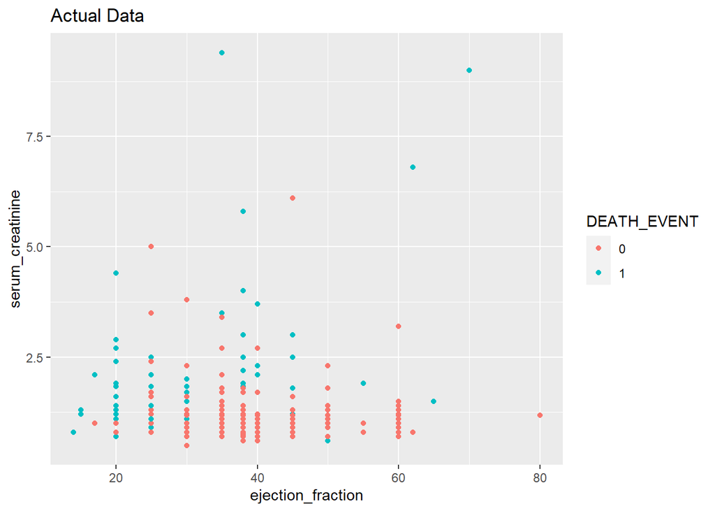

```r
df <- clinical_df
df$predict.1 <- predict(lrmodel.1, df,type = "response")
df$predict.2 <- predict(lrmodel.2, df,type = "response")
df$predict.3 <- predict(lrmodel.3, df,type = "response")

ggplot(data = clinical_df, aes(y = serum_creatinine, x = ejection_fraction , color = DEATH_EVENT)) +
  geom_point() + ggtitle("Actual Data")
```

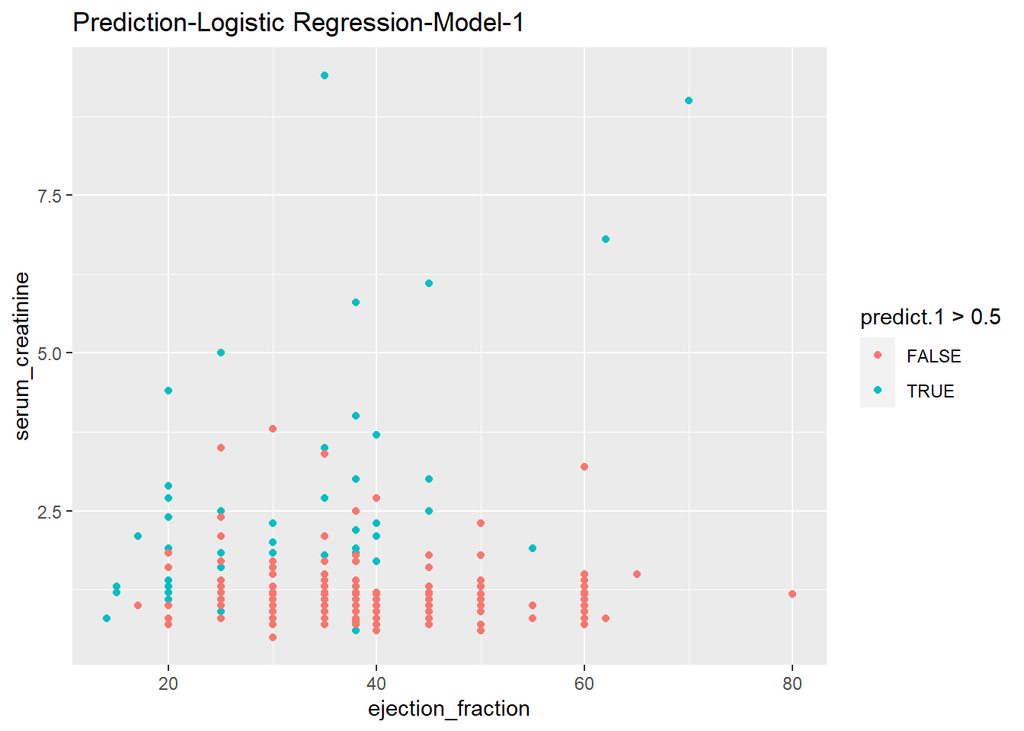

```r
ggplot(data = df, aes(y = serum_creatinine, x = ejection_fraction, color = predict.1>0.5)) +
  geom_point() + ggtitle("Prediction-Logistic Regression-Model-1")
```

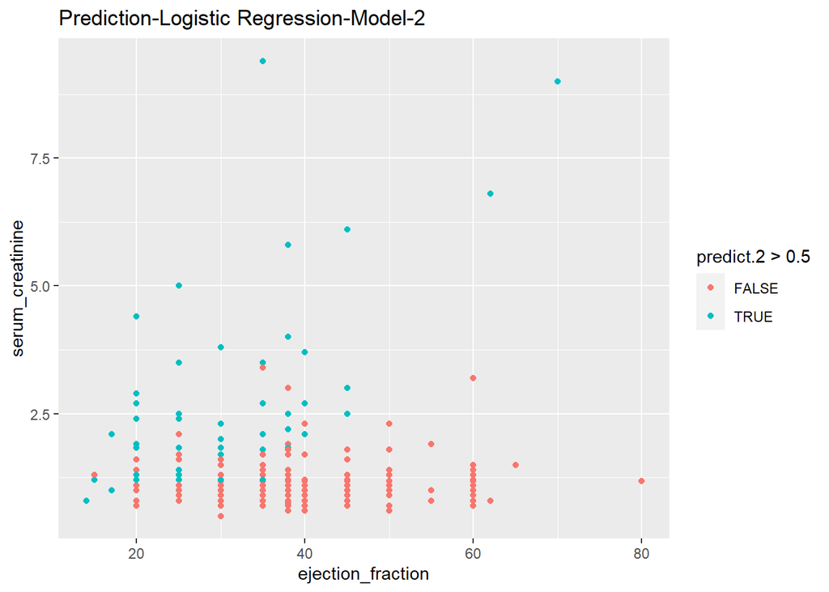

```r
ggplot(data = df, aes(y = serum_creatinine, x = ejection_fraction, color = predict.2>0.5)) +
  geom_point() + ggtitle("Prediction-Logistic Regression-Model-2")
```

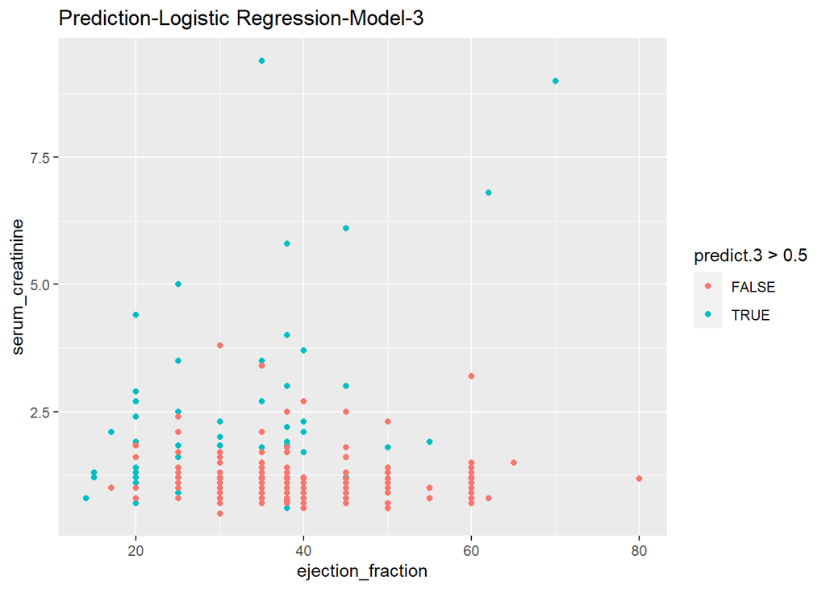

```r
ggplot(data = df, aes(y = serum_creatinine, x = ejection_fraction, color = predict.3>0.5)) +
  geom_point() + ggtitle("Prediction-Logistic Regression-Model-3")
```

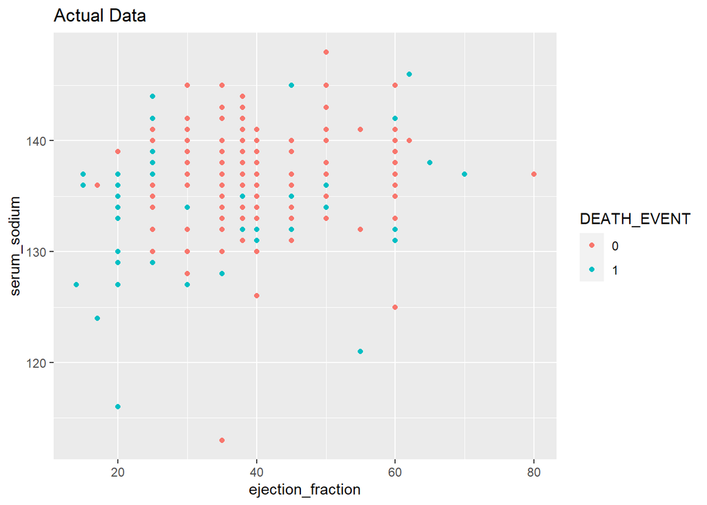

```r
df <- clinical_df
df$predict.1 <- predict(lrmodel.1, df,type = "response")
df$predict.2 <- predict(lrmodel.2, df,type = "response")
df$predict.3 <- predict(lrmodel.3, df,type = "response")

ggplot(data = clinical_df, aes(y = serum_sodium, x = ejection_fraction , color = DEATH_EVENT)) +
  geom_point() + ggtitle("Actual Data")
```

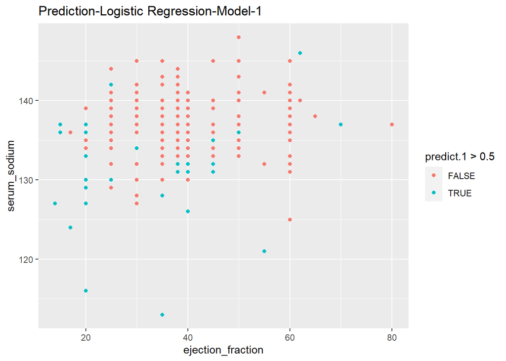

```r
ggplot(data = df, aes(y = serum_sodium, x = ejection_fraction, color = predict.1>0.5)) +
  geom_point() + ggtitle("Prediction-Logistic Regression-Model-1")
```

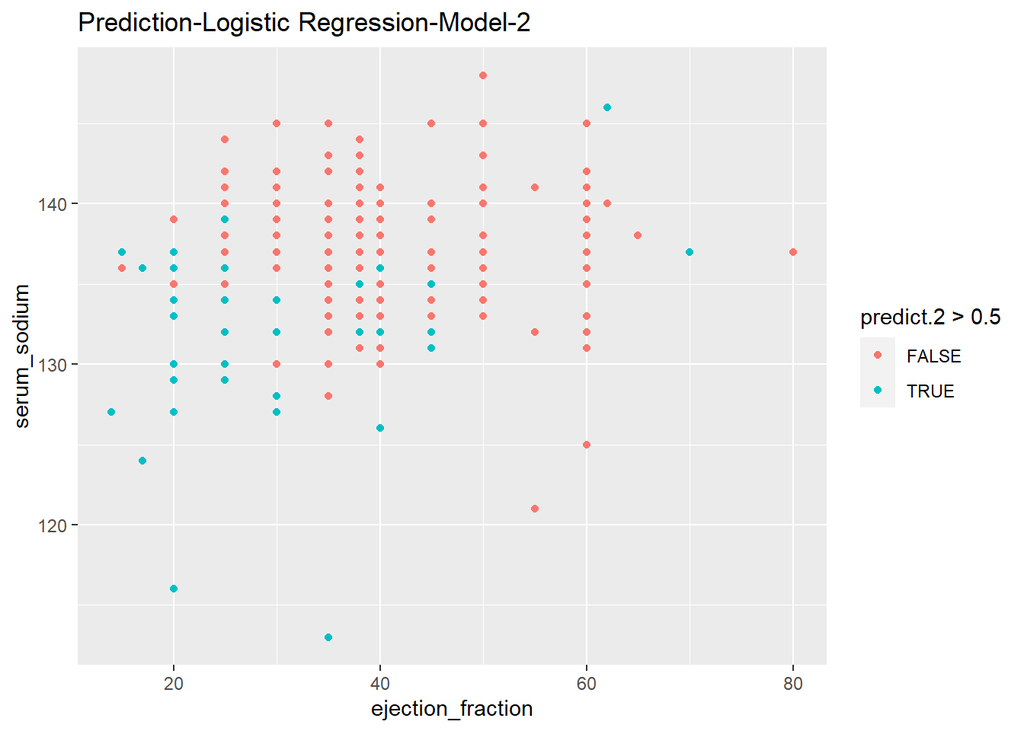

```r
ggplot(data = df, aes(y = serum_sodium, x = ejection_fraction, color = predict.2>0.5)) +
  geom_point() + ggtitle("Prediction-Logistic Regression-Model-2")
```

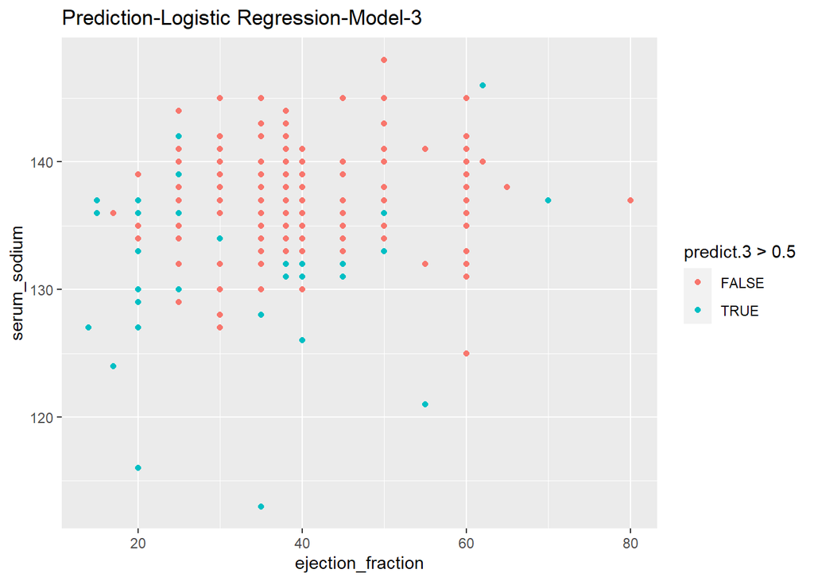

```r
ggplot(data = df, aes(y = serum_sodium, x = ejection_fraction, color = predict.3>0.5)) +
  geom_point() + ggtitle("Prediction-Logistic Regression-Model-3")
```

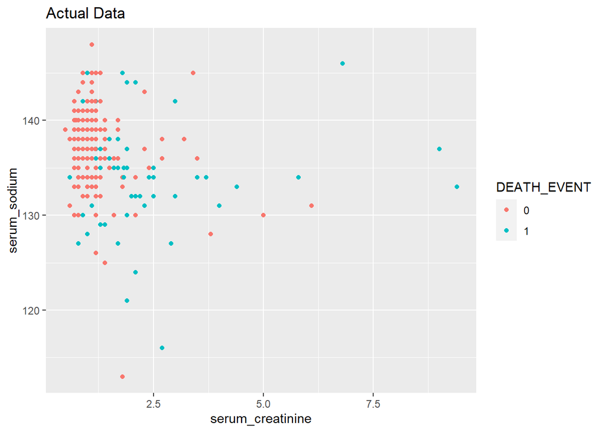

```r
df <- clinical_df
df$predict.1 <- predict(lrmodel.1, df,type = "response")
df$predict.2 <- predict(lrmodel.2, df,type = "response")
df$predict.3 <- predict(lrmodel.3, df,type = "response")

ggplot(data = clinical_df, aes(y = serum_sodium, x = serum_creatinine , color = DEATH_EVENT)) +
  geom_point() + ggtitle("Actual Data")
```

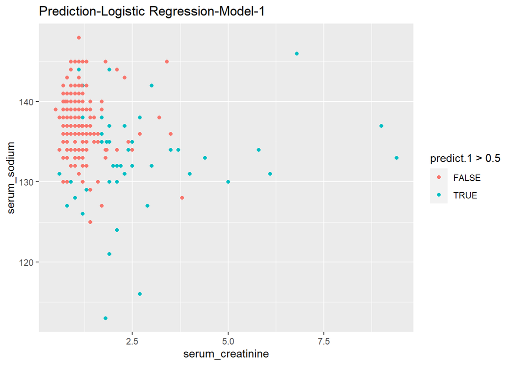

```r
ggplot(data = df, aes(y = serum_sodium, x = serum_creatinine, color = predict.1>0.5)) +
  geom_point() + ggtitle("Prediction-Logistic Regression-Model-1")
```

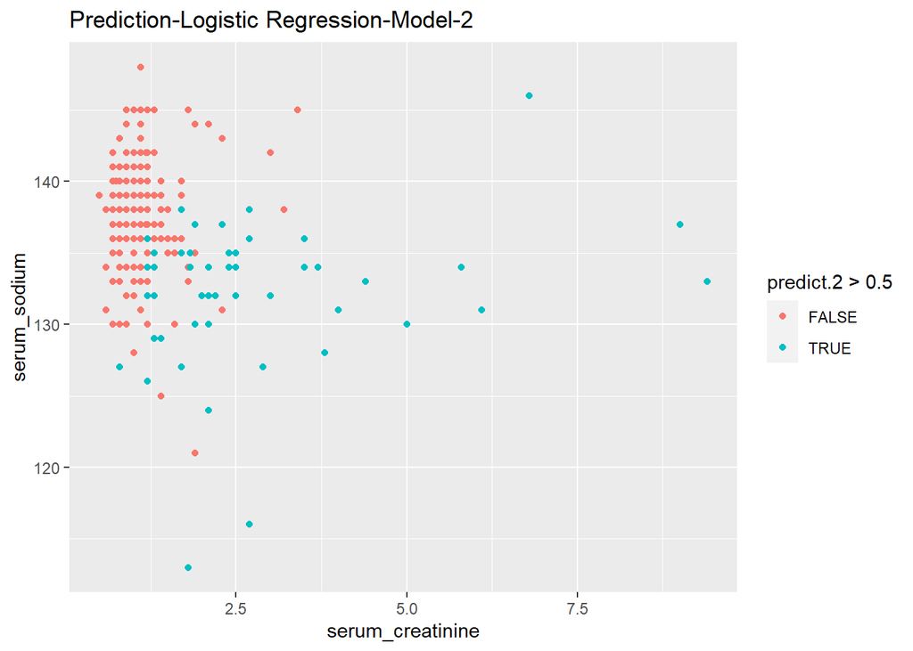

```r
ggplot(data = df, aes(y = serum_sodium, x = serum_creatinine, color = predict.2>0.5)) +
  geom_point() + ggtitle("Prediction-Logistic Regression-Model-2")
```

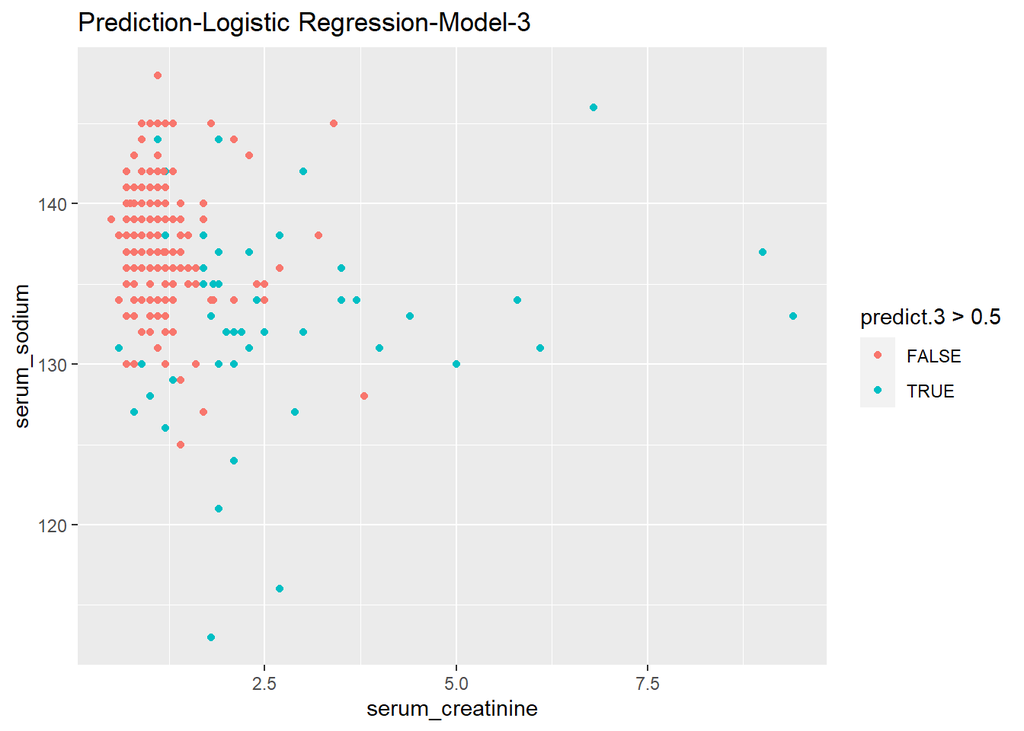

```r
ggplot(data = df, aes(y = serum_sodium, x = serum_creatinine, color = predict.3>0.5)) +
  geom_point() + ggtitle("Prediction-Logistic Regression-Model-3")
```

# Summary

We do see some relation between some parameters/variables on the mortality. The most important one’s are

1. Ejection Fraction - If the % age is lesser, Risk increases.
2. Creatinine Level - Wit increase in level, Risk increases.
3. Sodium Level - With decrease in level, Risk increases.
4. Age - Older the patient, higher the risk

Another factor which I did not plan earlier was

1. Time in days between follow up visits.

The other factors which I observed, did not show much effect.

We were able to generate a prediction model(a logistic regression model), which is shown as “lrmodel.3” in the analysis.

There were some concerns regarding the sample size of the data. Since the data was from a single location, there might be some other factors in play which can be due to habits of people to that specific region or part of the world and may not be reflecting in the data. If we get more geographically separated data, we might come up with better model. This model may be more effective in the region where data comes from.

# References

http://www.sthda.com/english/wiki/ggplot2-histogram-plot-quick-start-guide-r-software-and-data-visualization https://towardsdatascience.com/k-nearest-neighbors-algorithm-with-examples-in-r-simply-explained-knn-1f2c88da405c https://kevinzakka.github.io/2016/07/13/k-nearest-neighbor/ https://www.datacamp.com/community/tutorials/k-means-clustering-r Discovering Statistics Using R, Andy Field | Jeremy Miles | Zoe Field R For Everyone, Jared P Lander